# Rise of three n

Sumer Verma

12/9/2021

## Motivation and Overview

The National Basketball Association (NBA) is a professional basketball league in North America and has become one of the most beloved sports leagues around the world. Having been around since 1946 the NBA has constantly evolved the sport of basketball to be more exciting over the past 7 decades. While many of these measures to transform the game in the NBA took place through a variety rule changes, innovative coaches and dominant players, one change that has shifted basketball drastically in a short period has been the vastly increased use of the Three Point shot during the preceding decade. As an NBA fan the goal of this project was to understand how analytics proliferated the use of the 3 point shot and attempt to understand which teams influenced the explosion of offense in the league. To give a deeper understanding of the state of the league today, analyzing data and a background in NBA history will serve as a primer to identify different aspects of the NBA that have affected the rise of the Three.

## Project Objectives

The main objective of this project was to use data to identify and visualize the specific variables or trends that have caused an offensive shift in the league. Using this data in relation to different chunks of NBA history, I can present a compelling argument to why the game has shifted towards the increased use of the 3 Point Shot.

## Target Audience

The target audience for this project is anyone with an interest in data exploration and all NBA fans. In the report I have also included the data sets I used to create these visualizations and to display the major findings of the project.

## History

When the NBA was first established in 1946, there were only 11 franchises and for 30 years the league competed with the rival organization known as the ABL (American Basketball League). During this time period neither league had a 3 point line on the court and points could only be scored by successfully making a layup, 2 point jump shot or a free-throw. While this model had been used since basketball was created by Dr. James Naismith in 1891, the ABL which was in dire financial straits decided to institute a 3 point shot in 1961 in an attempt to create a more exciting league. However, the ABL shut down in 1963 and became the ABA (American Basketball Association) which used the 3 point shot and slam dunk in an attempt to compete with the NBA. While the ABA would stay competitive with the NBA, it shut down 9 seasons later only to be acquired by the NBA. The increased revenue and innovative rules acquired from the former ABA led the 3 point shot to be adopted by the league. To understand the three point shot offensive basketball must be understood in the segments. These components are categorized as free throws, layups, mid-range jump shots and three pointers. The above-mentioned components are worth different values of points with a single successful free throw worth 1 point, and layups and mid-range jumpers as 2 points. The league only consisted of the aforementioned parts until 1979, when the NBA officially adopted 3 point line into its rule base. Despite the creation of a new component of offensive basketball people felt a line 22 feet away from the rim was a gimmick. George Mikan a former player and commissioner of the ABA argued in favor of the new rule as he stated it “ would give the smaller player a chance to score and open up the defense to make the game more enjoyable for fans”(Schuhmann). While the rule change was fully adopted by the 1980’s many players would not attempt three’s, in the first year of its inception most teams average less than three 3-point attempts per game, 4 decades later teams are averaging 23.7 attempts each game.

##Exploratory Data Analysis Player Level

## Including Plots

```
## [1] "data.frame"
```

```
##         Year           Player X3p
## 1 1979-12-11     Brian Taylor  90
## 2 1980-12-11       Mike Bratz  57
## 3 1981-12-11         Don Buse  73
## 4 1982-12-11    Mike Dunleavy  67
## 5 1983-12-11 Darrell Griffith  91
## 6 1984-12-11 Darrell Griffith  92
```

```
##          Year           Player X3p
## 1  1979-12-11     Brian Taylor  90
## 2  1980-12-11       Mike Bratz  57
## 3  1981-12-11         Don Buse  73
## 4  1982-12-11    Mike Dunleavy  67
## 5  1983-12-11 Darrell Griffith  91
## 6  1984-12-11 Darrell Griffith  92
## 7  1985-12-11       Larry Bird  82
## 8  1986-12-11       Larry Bird  90
## 9  1987-12-11      Danny Ainge 148
## 10 1988-12-11    Michael Adams 166
## 11 1989-12-11    Michael Adams 158
## 12 1990-12-11   Vernon Maxwell 172
## 13 1991-12-11   Vernon Maxwell 162
## 14 1992-12-11    Reggie Miller 167
```

[output cut: 28 more lines]

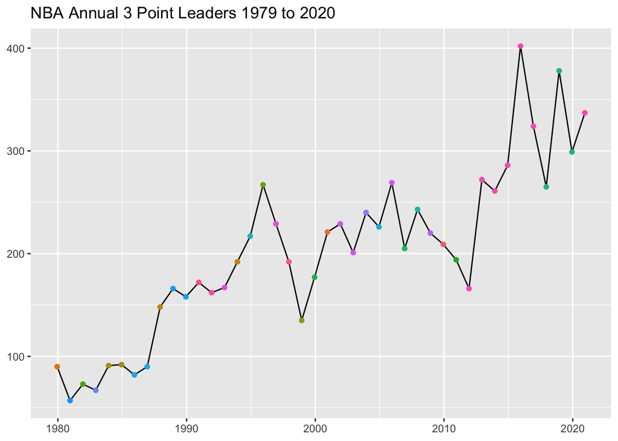

The relationship of Stephen Curry being the highest volume 3 point shooter in terms of total attempts and made shots, makes him arguably the largest individual outlier in NBA history. Curry’s success in a league dominated by tall athletic Forwards was exceptional, this is due to his ability to make three point shots which cancelled the Meta (Most effective tactic) of aggressively driving to the rim for a layup or dunk or taking a 2 point mid-range jumper, which had largely dominated the league since the 1980’s. One key factor in Curry’s success was his ability to change the definition of being a shooter in the league. For many years in the league after the advent of the 3 point line, players that shot threes were specialists, meaning there only job on offense was to get free themselves to get a pass for an open three. Many of these players including Peja Stojakovich who was the 2003 league point leader as shown above, were spot up shooters taking a limited number of 3’s at specific points in the game. The drastic change caused by Steph was creating a new type of 3 point shooter or volume shooter, where a majority of their shot attempts came from beyond the 3 point line. The following figure shows the overall ratio of the 2016 Golden State Warriors, with Steph Curry’s record breaking season in comparison with his teammates. This shows Steph Curry’s total 2 point field goals and 3 point field goals made in a ratio with one another. Unlike his teammates a majority of Curry’s points came from volume 3 point shooting, for a league which had never seen high volume 3 point shooters an equal ratio of 3 point and 2 point fields goals made doubled his scoring output. The record breaking years by Curry while seemingly divergent, have influenced a greater trend of volume shooters in the NBA. The 4 years following Curry’s 2016 year there were 10 players who made more than 250 threes, this was a rapid shift in a small period for a league that had only seen 3 other players make 250 or more 3-Pt field goals from 1979 to 2012.

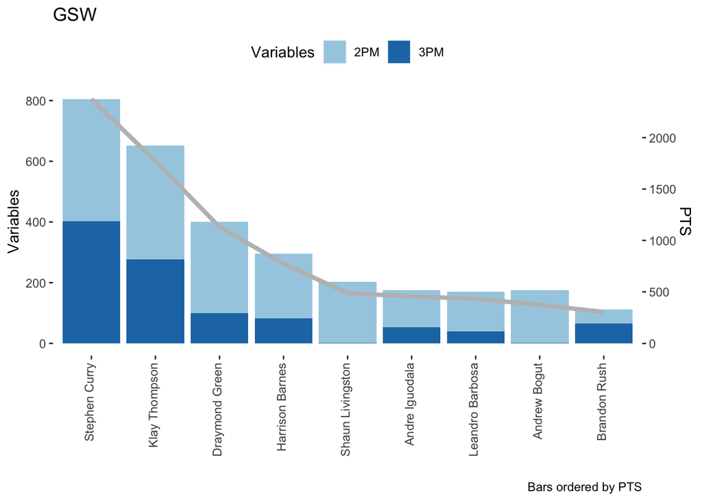

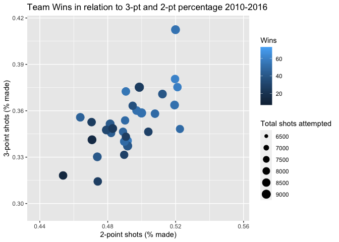

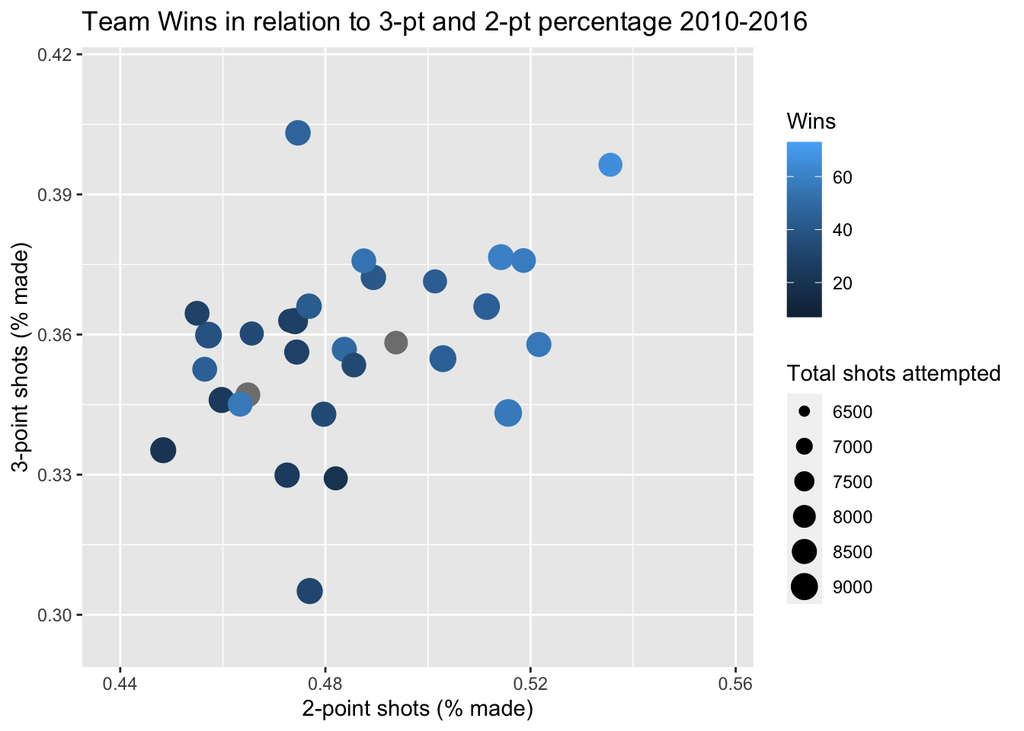

## Data Wrangling/Source

Most of the data was collected from the Basketball references database (https://www.basketball-reference.com). The data on this website was pulled using an API with the use of the nbaStatsR library. The database contains player statistics including points per game, shot attempts per game, etc. The data base also provides team statistics for each organization in the NBA including wins, team field goal percentage etc.

## Supplements

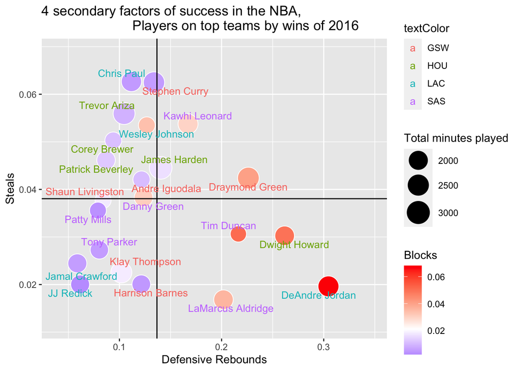

## Citations

Schuhmann, John, and Archive. “NBA’s 3-Point Revolution: How 1 Shot Is Changing the Game.” NBA.com, Oct. 2020, https://www.nba.com/news/3-point-era-nba-75.

Zs. “Moreyball: The Houston Rockets and Analytics.” Digital Innovation and Transformation, 5 Apr. 2015, https://digital.hbs.edu/platform-digit/submission/moreyball-the-houston-rockets-and-analytics.